# Problem Set 3

Author

Ludovico Sinigaglia

Published

November 1, 2026

**GitHub repo:** https://github.com/ludsin/ec422_ps3_Sinigaglia

```r
# Load packages
library(tidyverse)
library(fpp3)
library(seasonal)

# Import retail sales data
retail_raw <- read_csv(
  "data/retail_sales_raw.csv",
  na = ".",
  col_types = cols(
    observation_date = col_date(format = "%Y-%m-%d"),
    RSAFS = col_double(),
    RSAFSNA = col_double()
  )
)

# Create retail sales tsibble
retail_ts <- retail_raw |>
  pivot_longer(
    cols = c(RSAFS, RSAFSNA),
    names_to = "series_id",
    values_to = "sales"
  ) |>
  mutate(Month = yearmonth(observation_date)) |>
  as_tsibble(index = Month, key = series_id)

# Create Canadian gas tsibble
can_gas <- canadian_gas |>
  select(Month, Volume)
```

## Time and Tsibbles

**U.S. Retail Sales (`retail_ts`)**

For the first dataset, I used U.S. retail sales data from FRED, originally collected by the U.S. Census Bureau. The data are monthly and include two versions of retail sales: one that is seasonally adjusted (RSAFS) and one that is not (RSAFSNA). Both are measured in millions of dollars. The index is `Month`, which keeps track of time, while the key is `series_id`, which allows R to tell the two series apart.

**Canadian Natural Gas Production (`can_gas`)**

For the second dataset, I used Canadian natural gas production data from the `fpp3` package in R. It shows monthly gas production from January 1960 to February 2005, measured in billions of cubic meters. Like the retail sales dataset, it uses `Month` as its time index. However, it doesn’t need a key because it only contains one series.

### 2.6b

By looking at the monthly averages since 1990 I found that December has the highest natural gas production at around 17.1 billion cubic meters, while June has the lowest at around 14.9 billion. This suggests that gas production follows a seasonal pattern with higher levels during the colder months and lower levels in summer

```r
can_gas_recent <- can_gas |>
  filter(Month >= yearmonth("1990 Jan")) |>
  mutate(month = month(Month, label = TRUE))

can_gas_recent |>
  as_tibble() |>
  group_by(month) |>
  summarize(avg_volume = mean(Volume)) |>
  knitr::kable(digits = 2)
```

| month | avg_volume |
| --- | --- |
| Jan | 16.99 |
| Feb | 15.28 |
| Mar | 16.34 |
| Apr | 15.74 |
| May | 15.75 |
| Jun | 14.94 |
| Jul | 15.60 |
| Aug | 15.62 |
| Sep | 15.13 |
| Oct | 16.16 |
| Nov | 16.18 |
| Dec | 17.15 |

### 2.6d

I used `sum()` instead of `mean()` because I wanted to calculate the total gas production for each quarter rather than the average monthly production. By adding the three months together, I can see how much gas was produced during the whole quarter. Also looking at the graph, I can still see a seasonal pattern, with peaks and drops that repeat over time and this shows that seasonality is still present even when I change the data from monthly to quarterly

```r
can_gas_q <- can_gas |>
  filter(Month <= yearmonth("2004 Dec")) |>
  index_by(Quarter = yearquarter(Month)) |>
  summarize(Volume = sum(Volume))

knitr::kable(head(can_gas_q), digits = 2)
```

| Quarter | Volume |
| --- | --- |
| 1960 Q1 | 4.14 |
| 1960 Q2 | 3.30 |
| 1960 Q3 | 2.97 |
| 1960 Q4 | 4.26 |
| 1961 Q1 | 5.01 |
| 1961 Q2 | 4.17 |

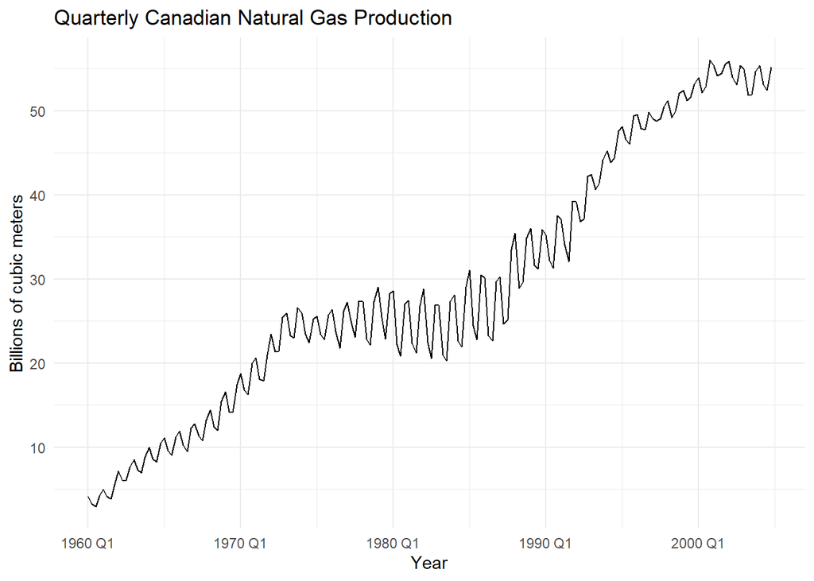

```r
can_gas_q |>
  autoplot(Volume) +
  labs(
    title = "Quarterly Canadian Natural Gas Production",
    x = "Year",
    y = "Billions of cubic meters"
  ) +
  theme_minimal()
```